# rym: Загрузка данных о расходах в Яндекс Метрику

Alexey Seleznev

2020-10-16

Начиная с версии `rym 0.7.0` в пакет были добавлены 3 функции для управления загрузкой данных о расходах на рекламу в Яндекс.Метрике.

- `rym_upload_expense()` - Загрузка расходов в Яндекс.Метрику
- `rym_delete_uploaded_expense()` - Удаление данных о расходах из Яндекс.Метрики
- `rym_get_uploadings_expense()` - Список загрузок расходов

## Аргументы которые присутвуют в функциях:

- counter - номер счётчика в который необходимо загрузить данные
- data - data.frame, содержащий данные о расходах на рекламу которые требуется загрузить в Яндекс.Метрику
- comment - комментарий к загрузке (не обязательно)
- login - ваш лошин в яндексе
- token.path - путь к папке в которой хранятся учётные данные

## Формат данных для загрузки

data.frame содержащий данные о расходах должен иметь следующую структуру:

### Обязательные поля

- Date — строка, дата в формате YYYY-MM-DD или диапазон дат в формате YYYY-MM-DD/YYYY-MM-DD.
- UTMSource — строка, значение метки utm_source.
- Expenses — число, сумма, которая была потрачена на рекламу без учета НДС. Десятичным разделителем является точка.

### Необязательные поля:

- UTMMedium — строка, значение метки utm_medium.
- UTMCampaign — строка, значение метки utm_campaign.
- UTMTerm — строка, значение метки utm_term.
- UTMContent — строка, значение метки utm_content.
- Currency — строка, трехбуквенный код валюты по ISO 4217.
- Clicks — число, количество кликов по рекламным объявлениям.

## Пример подготовки, загрузки и удаленния данных

```r
# данные для загрузки
expense <- data.frame(Date        = c("2020-06-01",
                                      "2020-06-02"),
                      UTMSource   = c("test_s_1",
                                      "test_s_2"),
                      Expenses    = c(88.12,
                                      92.11),
                      UTMMedium   = c("cpc",
                                      "cpm"),
                      UTMCampaign = c("camp1",
                                      "camp2"),
                      UTMTerm     = c("term1",
                                      "term2"),
                      UTMContent  = c("cont1",
                                      "cont2"),
                      Currency    = c("RUB",
                                      "RUB"),
                      Clicks      = c(11, 15))

# отправка данных в Яндекс.Метрику
rym_upload_expense(counter = 11111,
                   data    = expense,
                   login   = 'yandex_login',
                   token.path = "D:/packlab/rym")

# Удаление данных из Яндекс.Метрики
rym_delete_uploaded_expense(counter = 11111,
                            data    = expense,
                            login   = 'yandex_login',
                            token.path = "D:/packlab/rym")

# получение списка загрузок
loaded <- rym_get_uploadings_expense(counter = 11111,
                                     login   = 'yandex_login',
                                     token.path = "D:/packlab/rym")
```

## Как найти загруженные данные в интерфейсе Яндекс.Метрики

Отправленные данные можно найти в отчёте “Источники, расходы и ROI”

Где найти отчёт:

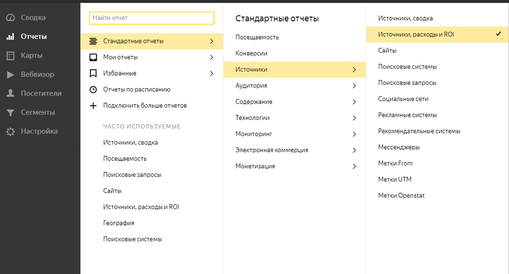

Отчёт:

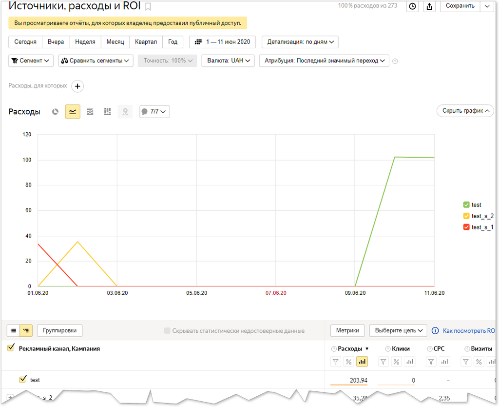

## Ссылки

- [Документация к API методам](https://yandex.ru/dev/metrika/doc/api2/management/expenses/uploadbody-docpage/)
- [Об учёте расходов на рекламу](https://yandex.ru/support/metrica/ad/expenses.html#expences)